# Clase 1 - R basico

David Hervás

14/12/2018

# Instrucciones básicas de R

El intérprete de R se puede utilizar como una simple calculadora

```r
3+5
```

```
## [1] 8
```

```r
12+2^3
```

```
## [1] 20
```

```r
3*(2+5)
```

```
## [1] 21
```

```r
sqrt(16)
```

```
## [1] 4
```

Dentro de las funciones más básicas está la de asignación, que nos sirve para almacenar valores en objetos

```r
x <- 11
y <- 12
x+y
```

```
## [1] 23
```

En R el símbolo de asignación recomendado es ‘<-’, aunque puede utilizarse también ‘=’:

```r
x = 14
x
```

```
## [1] 14
```

Incluso se puede usar como asignacion ‘->’

```r
y <- 3 -> x
x
```

```
## [1] 3
```

```r
y
```

```
## [1] 3
```

## Estructuras de datos

### Escalar

```r
x <- 5
x
```

```
## [1] 5
```

### Vector

Si combinamos varios escalares a lo largo de una dimensión, formamos un vector

```r
x <- c(1, 2, 3, 4, 5, 6, 7, 8, 9, 10)
x
```

```
##  [1]  1  2  3  4  5  6  7  8  9 10
```

En realidad, los escalares en R son vectores de longitud 1

### Matriz

Si combinamos varios vectores a lo largo de una segunda dimensión formamos una matriz

```r
x2 <- matrix(x, ncol=2)
x2
```

```
##      [,1] [,2]
## [1,]    1    6
## [2,]    2    7
## [3,]    3    8
## [4,]    4    9
## [5,]    5   10
```

```r
cat("\n")
```

```r
x3 <- matrix(x, byrow = TRUE, ncol=2)
x3
```

```
##      [,1] [,2]
## [1,]    1    2
## [2,]    3    4
## [3,]    5    6
## [4,]    7    8
## [5,]    9   10
```

### Array

Podemos seguir combinando a lo largo de más dimensiones, por ejemplo la combinación de varias matrices

```r
x3 <- array(x, dim=c(2, 1, 5))
x3
```

```
## , , 1
##
##      [,1]
## [1,]    1
## [2,]    2
##
## , , 2
##
##      [,1]
## [1,]    3
## [2,]    4
##
## , , 3
##
##      [,1]
## [1,]    5
## [2,]    6
##
## , , 4
##
##      [,1]
## [1,]    7
## [2,]    8
##
## , , 5
##
##      [,1]
## [1,]    9
## [2,]   10
```

Podemos saber el tipo de objeto mediante la función class()

```r
class(x)
```

```
## [1] "numeric"
```

```r
class(x2)
```

```
## [1] "matrix"
```

```r
class(x3)
```

```
## [1] "array"
```

Todas las estructuras que hemos visto no tienen por qué ser numéricas. Pueden ser de caracteres

```r
x <- "a"
x
```

```
## [1] "a"
```

```r
x2 <- matrix(c("a", "b", "c", "d", "e", "f", "g", "h"), ncol=2)
x2
```

```
##      [,1] [,2]
## [1,] "a"  "e"
## [2,] "b"  "f"
## [3,] "c"  "g"
## [4,] "d"  "h"
```

O incluso lógicas

```r
x <- TRUE
x
```

```
## [1] TRUE
```

```r
x2 <- matrix(c(TRUE, TRUE, TRUE, FALSE, FALSE, TRUE), ncol=2)
x2
```

```
##      [,1]  [,2]
## [1,] TRUE FALSE
## [2,] TRUE FALSE
## [3,] TRUE  TRUE
```

```r
class(x)
```

```
## [1] "logical"
```

```r
class(x2)
```

```
## [1] "matrix"
```

En estos tipos de objeto no se pueden mezclar los tipos (numérico, carácter o lógico). Si se hace, se coerciona el resultado al tipo más general:

```r
c("a", "b", 1, 2)
```

```
## [1] "a" "b" "1" "2"
```

```r
c(TRUE, TRUE, 1, 2)
```

```
## [1] 1 1 1 2
```

```r
c("A", TRUE, 3)
```

```
## [1] "A"    "TRUE" "3"
```

### data.frame

Los data.frame son estructuras de datos más sofisticadas, ya que permiten la combinación de distintos tipos en un mismo objeto. Aunque deben ser de la misma longitud

```r
df <- data.frame(v1 = c("a", "b"), v2 = c(TRUE, FALSE), v3 = c(4, 5))
df
```

```
##   v1    v2 v3
## 1  a  TRUE  4
## 2  b FALSE  5
```

```r
class(df)
```

```
## [1] "data.frame"
```

```r
df$v1
```

```
## [1] a b
## Levels: a b
```

```r
class(df$v1)
```

```
## [1] "factor"
```

```r
class(df$v2)
```

```
## [1] "logical"
```

```r
class(df$v3)
```

```
## [1] "numeric"
```

### lista

Las listas son las estructuras de datos más generales, en el sentido de que pueden almacenar cualquier otro objeto de cualquier tipo y de cualquier longitud. Incluso pueden almacenar otras listas

```r
lista <- list("a", TRUE, c(1, 2), data.frame(v1 = c(1, 2, 3), v2 = c("A", "B", "C")))
lista
```

```
## [[1]]
## [1] "a"
##
## [[2]]
## [1] TRUE
##
## [[3]]
## [1] 1 2
##
## [[4]]
##   v1 v2
## 1  1  A
## 2  2  B
## 3  3  C
```

## Vectorización de operaciones

En R, la mayoría de las operaciones están vectorizadas, por lo que se aplican a lo largo de un vector por defecto

```r
x <- 10:1
x * 2
```

```
##  [1] 20 18 16 14 12 10  8  6  4  2
```

```r
x + 1
```

```
##  [1] 11 10  9  8  7  6  5  4  3  2
```

```r
y <- 1:10
x + y
```

```
##  [1] 11 11 11 11 11 11 11 11 11 11
```

```r
x * y
```

```
##  [1] 10 18 24 28 30 30 28 24 18 10
```

## Subsetting

Se entiende por subsetting la selección de un subconjunto de los datos contenidos en un objeto determinado. En general, el operador para su realización es el corchete ‘[]’, aunque en data.frame también se puede utilizar el dolar ‘$’ y en listas se puede utilizar el doble corchete ‘[[]]’

### En vectores

El valor o valores dentro del corchete determinan las posiciones que se seleccionan.

```r
x[1]
```

```
## [1] 10
```

```r
x[10]
```

```
## [1] 1
```

```r
x[1:4]
```

```
## [1] 10  9  8  7
```

```r
x[-(1:4)]
```

```
## [1] 6 5 4 3 2 1
```

```r
x[c(1, 3, 5, 7, 9)]
```

```
## [1] 10  8  6  4  2
```

```r
x[seq(1, 9, by = 2)]
```

```
## [1] 10  8  6  4  2
```

```r
rev(rev(x)[1])
```

```
## [1] 1
```

A diferencia de python, el operador ‘-’ no sirve para seleccionar empezando por el final, sino para eliminar datos

### En matrices y data.frame

En este caso se pueden seleccionar filas

```r
x2 <- matrix(1:30, ncol=3)
x2
```

```
##       [,1] [,2] [,3]
##  [1,]    1   11   21
##  [2,]    2   12   22
##  [3,]    3   13   23
##  [4,]    4   14   24
##  [5,]    5   15   25
##  [6,]    6   16   26
##  [7,]    7   17   27
##  [8,]    8   18   28
##  [9,]    9   19   29
## [10,]   10   20   30
```

```r
x2[1, ]
```

```
## [1]  1 11 21
```

```r
x2[1, ,drop=FALSE]
```

```
##      [,1] [,2] [,3]
## [1,]    1   11   21
```

```r
x2[1:3, ]
```

```
##      [,1] [,2] [,3]
## [1,]    1   11   21
## [2,]    2   12   22
## [3,]    3   13   23
```

Columnas

```r
x2[, 2]
```

```
##  [1] 11 12 13 14 15 16 17 18 19 20
```

```r
x2[, 2, drop=FALSE]
```

```
##       [,1]
##  [1,]   11
##  [2,]   12
##  [3,]   13
##  [4,]   14
##  [5,]   15
##  [6,]   16
##  [7,]   17
##  [8,]   18
##  [9,]   19
## [10,]   20
```

Fijaos que si no añadimos el parámetro drop=FALSE, tras el subsetting ya no nos queda una matriz, sino que se simplifica a un vector.

Y también filas y columnas a la vez:

```r
x2[1:4, 2:3]
```

```
##      [,1] [,2]
## [1,]   11   21
## [2,]   12   22
## [3,]   13   23
## [4,]   14   24
```

### También se puede hacer subsetting por expresiones lógicas

```r
x
```

```
##  [1] 10  9  8  7  6  5  4  3  2  1
```

```r
x[c(TRUE, TRUE, FALSE, FALSE, FALSE, FALSE, FALSE, FALSE, FALSE, FALSE)]
```

```
## [1] 10  9
```

```r
x[x > 8]
```

```
## [1] 10  9
```

En este caso se seleccionan los elementos con una expresión lógica de TRUE

Por lo tanto en nuestro data.frame, si quisiéramos seleccionar únicamente las filas con valores de v3 superiores a 4:

```r
df
```

```
##   v1    v2 v3
## 1  a  TRUE  4
## 2  b FALSE  5
```

```r
df[df$v3 > 4, ]
```

```
##   v1    v2 v3
## 2  b FALSE  5
```

## Expresiones lógicas

Dada la importancia de las expresiones lógicas para realizar subsetting y manipular los datos, las repasamos a conninuación.

### Igualdad

```r
x <- 4
x == 3
```

```
## [1] FALSE
```

```r
x == 4
```

```
## [1] TRUE
```

### Desigualdad

```r
x != 3
```

```
## [1] TRUE
```

```r
x != 4
```

```
## [1] FALSE
```

### Mayor y menor que

```r
x > 8
```

```
## [1] FALSE
```

```r
x < 8
```

```
## [1] TRUE
```

### Mayor o igual y menor o igual que

```r
x >= 4
```

```
## [1] TRUE
```

```r
x <= 4
```

```
## [1] TRUE
```

### Contenido en

```r
x %in% 3
```

```
## [1] FALSE
```

```r
x %in% 4
```

```
## [1] TRUE
```

```r
x %in% c(3, 4)
```

```
## [1] TRUE
```

En este último caso, no sería válido usar ‘==’, ya que R vectoriza y nos devolvería un resultado distinto

```r
x == c(3, 4)
```

```
## [1] FALSE  TRUE
```

### Negación

Devuelve la expresión lógica contraria

```r
!TRUE
```

```
## [1] FALSE
```

```r
x == 4
```

```
## [1] TRUE
```

```r
!x == 4
```

```
## [1] FALSE
```

### Combinación de expresiones lógicas

Las expresiones lógicas pueden combinarse con distintos operadores

El operador ‘&’ implica que se tienen que cumplir las dos condiciones para devolver TRUE

```r
x[x > 2 & x < 8]
```

```
## [1] 4
```

El operador ‘|’ (or) implica que se tiene que cumplir al menos una de las dos condiciones para devolver TRUE

```r
x[x < 2 | x > 8]
```

```
## numeric(0)
```

El operador ‘xor’ implica que se tiene que cumplir o una o la otra condición, pero no las dos a la vez

```r
x[xor(x < 2, x %in% c(1, 3, 5))]
```

```
## numeric(0)
```

## Valores especiales: El NA

El valor de NA está reservado para representar a los valores ausentes (Not Available). El problema de NA es que no se lleva bien con los operadores lógicos

```r
x <- c(1, 2, 3, 4, NA, 6, 7, 8, 9, 10)
x * 2
```

```
##  [1]  2  4  6  8 NA 12 14 16 18 20
```

```r
x + 1
```

```
##  [1]  2  3  4  5 NA  7  8  9 10 11
```

```r
x[x < 2]
```

```
## [1]  1 NA
```

```r
x[x > 2]
```

```
## [1]  3  4 NA  6  7  8  9 10
```

```r
x[x == 2]
```

```
## [1]  2 NA
```

Si queremos ser restrictivos y eliminar los NA al hacer subsetting, hay que buscar alguna alternativa:

### Para la igualdad, usar el operador ‘%in%’

```r
x[x == 4]
```

```
## [1]  4 NA
```

```r
x[x %in% 4]
```

```
## [1] 4
```

### Para <, >, <= y >=, usar las funciones %>NA%, %<NA%, %>=NA%, %<=NA% del paquete clickR

```r
library(clickR)
x[x < 2]
```

```
## [1]  1 NA
```

```r
x[x %<NA% 2]
```

```
## [1] 1
```

```r
x[x %<=NA% 4]
```

```
## [1] 1 2 3 4
```

### Filtrarlos a mano con la función especial is.na()

```r
x[x < 2 & !is.na(x)]
```

```
## [1] 1
```

## Comparadores lógicos especiales

Como ya se ha visto con is.na(), hay una serie de operadores especiales para determinar si un valor es de un tipo especial o no

```r
is.na(c(1, 2, 3, NA))
```

```
## [1] FALSE FALSE FALSE  TRUE
```

```r
is.infinite(c(1/0, log(0)))
```

```
## [1] TRUE TRUE
```

```r
is.nan(c(log(-1), NA))
```

```
## [1]  TRUE FALSE
```

```r
is.na(c(log(-1), NA))
```

```
## [1] TRUE TRUE
```

```r
is.null(NULL)
```

```
## [1] TRUE
```

```r
is.numeric(x)
```

```
## [1] TRUE
```

```r
is.character("a")
```

```
## [1] TRUE
```

```r
is.logical("TRUE")
```

```
## [1] FALSE
```

```r
is.logical(TRUE)
```

```
## [1] TRUE
```

```r
is.data.frame(df)
```

```
## [1] TRUE
```

## Otras operaciones con vectores, matrices y data.frames

### Combinar vectores en filas o columnas

```r
x <- c(1, 2, 3, 4, 5)
y <- c(6, 7, 8, 9, 10)

xy <- cbind(x, y)
xy
```

```
##      x  y
## [1,] 1  6
## [2,] 2  7
## [3,] 3  8
## [4,] 4  9
## [5,] 5 10
```

```r
rbind(x, y)
```

```
##   [,1] [,2] [,3] [,4] [,5]
## x    1    2    3    4    5
## y    6    7    8    9   10
```

```r
cbind(xy, y)
```

```
##      x  y  y
## [1,] 1  6  6
## [2,] 2  7  7
## [3,] 3  8  8
## [4,] 4  9  9
## [5,] 5 10 10
```

```r
rbind(xy, c(9, 9))
```

```
##      x  y
## [1,] 1  6
## [2,] 2  7
## [3,] 3  8
## [4,] 4  9
## [5,] 5 10
## [6,] 9  9
```

## Funciones de control de flujo

### Expresiones condicionales if… else

Este tipo de construcciones evalúan una expresión lógica y ejecutan una acción en el caso de que sea TRUE y (opcionalmente) ejecutan otra acción alternativa en el caso de que sea FALSE.

```r
x <- 8
if(x > 5) print("Hola")
```

```
## [1] "Hola"
```

```r
if(x < 5) print("Hola") else print("Adiós")
```

```
## [1] "Adiós"
```

En los casos con ‘else’, hay que tener especial cuidado con la sintaxis (quitar comentarios para probar)

```r
#if(x < 5) print("Hola")
#else print("Adiós")
```

Lo más seguro es meterlo todo en la misma linea o utilizar ‘{}’

```r
if(x < 5){
  print("Hola")
} else {
  print("Adiós")
}
```

```
## [1] "Adiós"
```

### Bucles for

¿Cómo se podría calcular cuanto suman los números del 1 al 10?

```r
p <- 0
for(i in 1:10){
  p <- p + i
}
p
```

```
## [1] 55
```

Aunque los bucles no suelen ser casi nunca la mejor opción en R

```r
sum(1:10)
```

```
## [1] 55
```

Otros ejemplos:

```r
for(i in 1:10){
  print(i^2)
}
```

```
## [1] 1
## [1] 4
## [1] 9
## [1] 16
## [1] 25
## [1] 36
## [1] 49
## [1] 64
## [1] 81
## [1] 100
```

```r
(1:10)^2
```

```
##  [1]   1   4   9  16  25  36  49  64  81 100
```

```r
x2 <- matrix(1:30, ncol=3)
for(i in 1:3) print(mean(x2[,i]))
```

```
## [1] 5.5
## [1] 15.5
## [1] 25.5
```

```r
colMeans(x2)
```

```
## [1]  5.5 15.5 25.5
```

Casi siempre se pueden sustituir por funciones de la familia apply

```r
apply(x2, 2, mean)
```

```
## [1]  5.5 15.5 25.5
```

```r
apply(x2, 1, mean)
```

```
##  [1] 11 12 13 14 15 16 17 18 19 20
```

### Bucles while

A diferencia de los for, que se sabe de antemano cuanto van a durar, estos siguen ejecutándose hasta que se alcance una condición determinada (que podría no alcanzarse nunca)

```r
library(numDeriv)
z <- function(x) 3*x^2-2*x-5
x <- 0.5

while(abs(z(x)) >= 0.001){
  x <- x - z(x)/genD(z, x)$D[1]
}
x
```

```
## [1] 1.666667
```

## Creación de funciones

Imaginemos que tenemos un proceso que consiste en sumarle a un número x una determinada cantidad y y luego multiplicar ese resultado por y.

```r
(2+3)*3
```

```
## [1] 15
```

```r
(2+4)*4
```

```
## [1] 24
```

```r
sumamulti <- function(x, y){
  (x+y)*y
}
sumamulti(2, 3)
```

```
## [1] 15
```

```r
sumamulti(2, 4)
```

```
## [1] 24
```

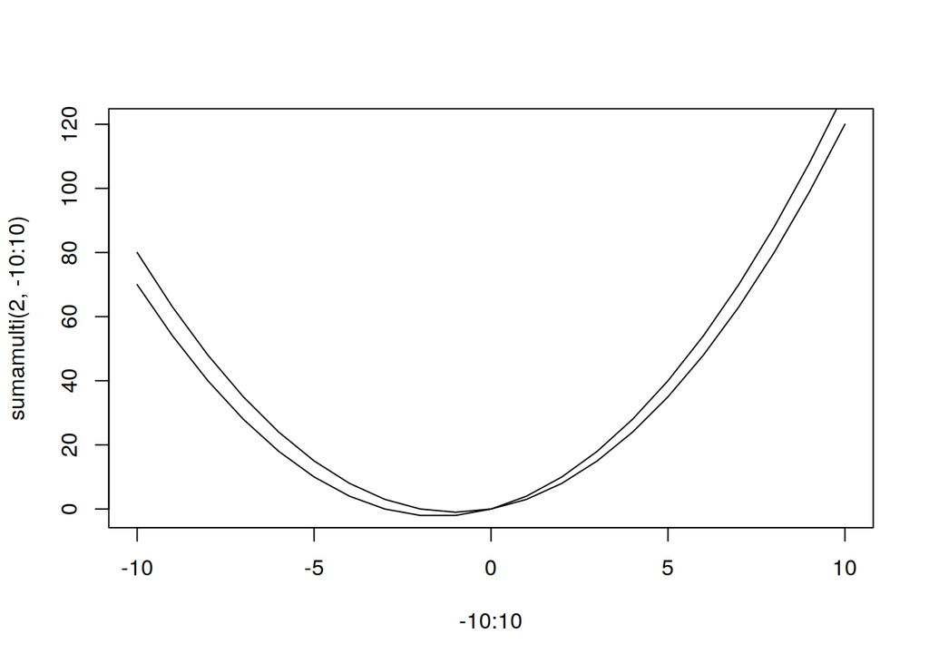

```r
plot(-10:10, sumamulti(2, -10:10), type="l")
lines(-10:10, sumamulti(3, -10:10))
```

## Importar datos

R puede importar datos de distintos softwares como SPSS, Stata, SAS, etc. Aunque lo más usado es el formato de texto plano en .csv.

```r
datos <- read.csv2("http://mural.uv.es/daherma/sce.csv")
datos
```

```
##      id edad sexo  fumador   SCE ardystil   riesgo
## 1     1   31    M moderado  9.40        1     bajo
## 2     2   44    F       no  5.92        0     bajo
## 3     3   27    M   severo  6.56        1     bajo
## 4     4   30    F moderado  7.10        0     bajo
## 5     5   29    M   severo 10.38        1  elevado
## 6     6   26    M       no  9.02        0     bajo
## 7     7   28    M   severo  8.14        1     bajo
## 8     8   29    M       no  5.82        0     bajo
## 9     9   30    M moderado 11.42        1  elevado
## 10   10   35    F   severo 10.84        0     bajo
## 11   11   28    M       no  8.90        1     bajo
## 12   12   37    F   severo  9.12        0     bajo
## 13   13   55    F       no  7.04        1     <NA>
## 14   14   48    F moderado  8.72        0     bajo
```

[output cut: 87 more lines]

```r
datos2 <- read.table("http://mural.uv.es/daherma/sce.csv", header=TRUE, sep=";", dec=",")
datos2
```

```
##      id edad sexo  fumador   SCE ardystil   riesgo
## 1     1   31    M moderado  9.40        1     bajo
## 2     2   44    F       no  5.92        0     bajo
## 3     3   27    M   severo  6.56        1     bajo
## 4     4   30    F moderado  7.10        0     bajo
## 5     5   29    M   severo 10.38        1  elevado
## 6     6   26    M       no  9.02        0     bajo
## 7     7   28    M   severo  8.14        1     bajo
## 8     8   29    M       no  5.82        0     bajo
## 9     9   30    M moderado 11.42        1  elevado
## 10   10   35    F   severo 10.84        0     bajo
## 11   11   28    M       no  8.90        1     bajo
## 12   12   37    F   severo  9.12        0     bajo
## 13   13   55    F       no  7.04        1     <NA>
## 14   14   48    F moderado  8.72        0     bajo
```

[output cut: 87 more lines]